# Progetto Fondamenti di Scienza dei Dati

## Come nasce il progetto

Il progetto riguardo al premio Nobel nasce per:

- curiosità personale
- interesse personale

Ragioni che hanno portato alla fomulazione delle seguenti domande:

- Quale paese ha vinto più premi nobel?
- Quanti ne ha vinti nel secolo corrente?
- Quanto ha speso tale paese in ricerca scientifica?
- Si può trovare una correlazione?
- Si può predirre il prossimo numero di vincitori?

## Dataset utilizzati

Per sviluppare il progetto sono stati utilizzati i seguenti dataset:

- [Vincitori Nobel](https://www.kaggle.com/datasets/prithusharma1/all-nobel-laureates-1901-present)
- [Totale speso in ricerca e sviluppo per paese](https://data.oecd.org/rd/gross-domestic-spending-on-r-d.htm)

Prelevati dalle seguenti fonti:

- Kaggle
- OECD (Organisation for Economic Co-operation and Development)

## Quale paese ha vinto più premi Nobel?

Osserviamo il numero di vincitori di dieci paesi scelti tra Europa e non.

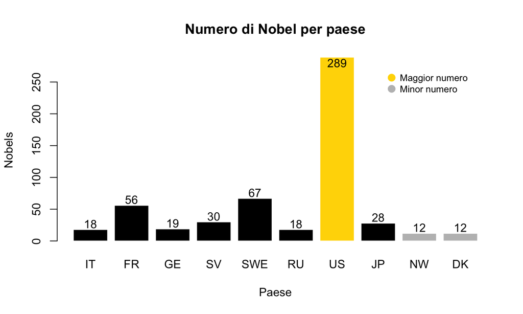

Consideriamo quindi gli **Stati Uniti** , in quali categorie hanno ottenuto il maggior numero di successi?

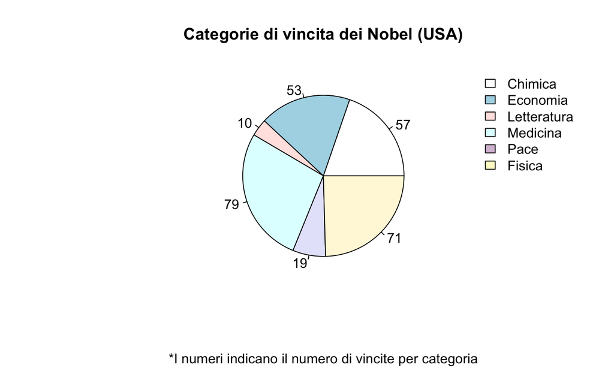

## Uno sguardo più da vicino

Ristringiamo ora il campo al periodo **2000-2021** e diamo un occhio più da vicino sia alle vincite che alle categorie di vincita.

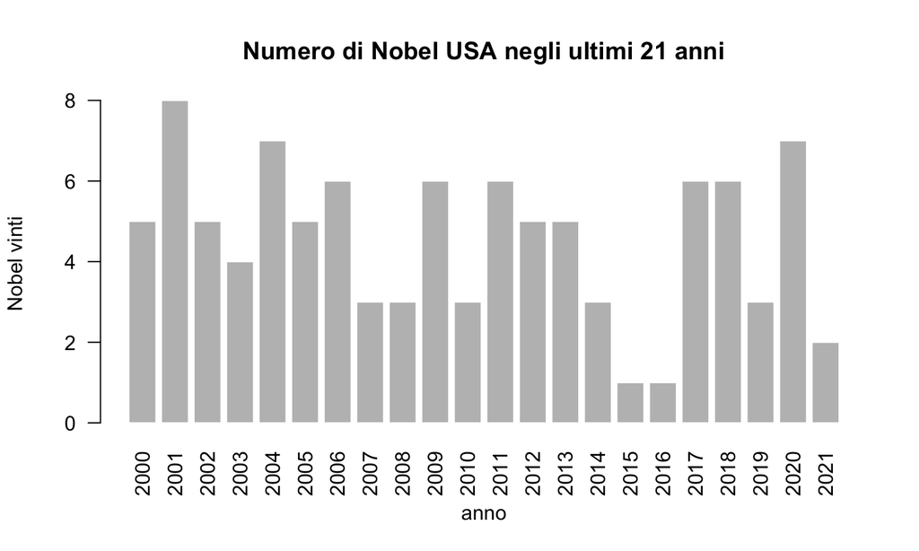

Osserviamo quindi anche le **categorie** più da vicino

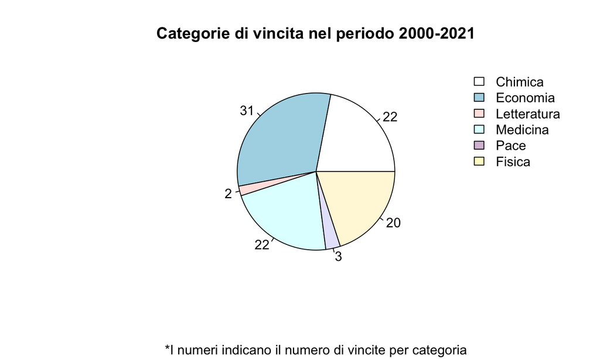

## Quanto ha speso tale paese in ricerca scientifica?

Cerchiamo ora di trovare una ragione dietro a tutte queste vincite. Osserviamo la spesa in ricerca e sviluppo negli ultimi 21 anni.

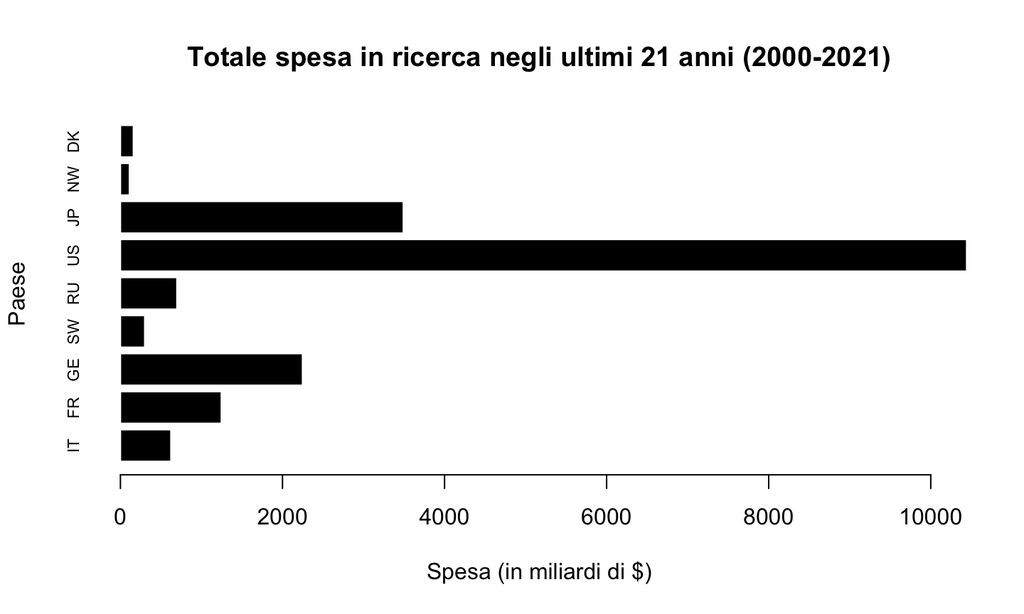

Osserviamo nuovamente le cose più da vicino per cercare di capire **l’evoluzione** di tale spesa per gli USA.

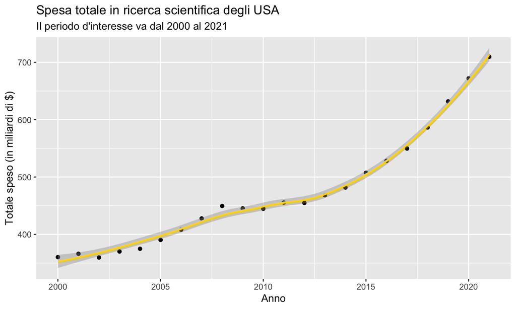

## Esiste una correlazione?

Cerchiamo di collegare le due cose provando a trovare una **correlazione tra la spesa in ricerca e il numero di premi Nobel vinti**.

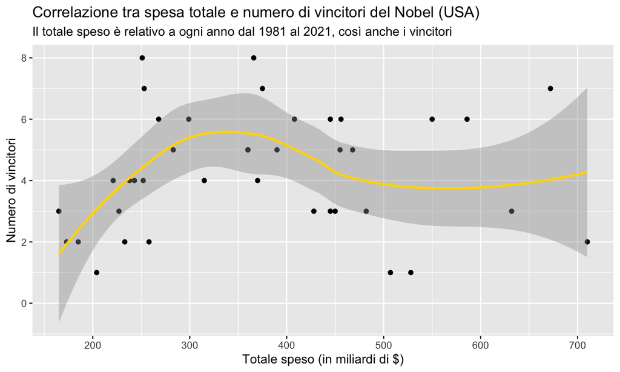

## E’ possibile predire le prossime vincite?

Cerchiamo quindi di collegare le cose, sviluppiamo un modello di **regressione lineare** per capire l’andamento della correlazione tra numero di vincitori e spesa totale:

Creiamo prima un indice di correlazione.

```
## [1] 0.09001746
```

Osserviamo anche i **coefficienti** e il **coefficiente di determinazione**

```
## (Intercept)       Value
## 3.825921409 0.001225902
```

```
## [1] 0.008103143
```

Tale indice è **positivo**, creiamo allora il modello di regressione lineare

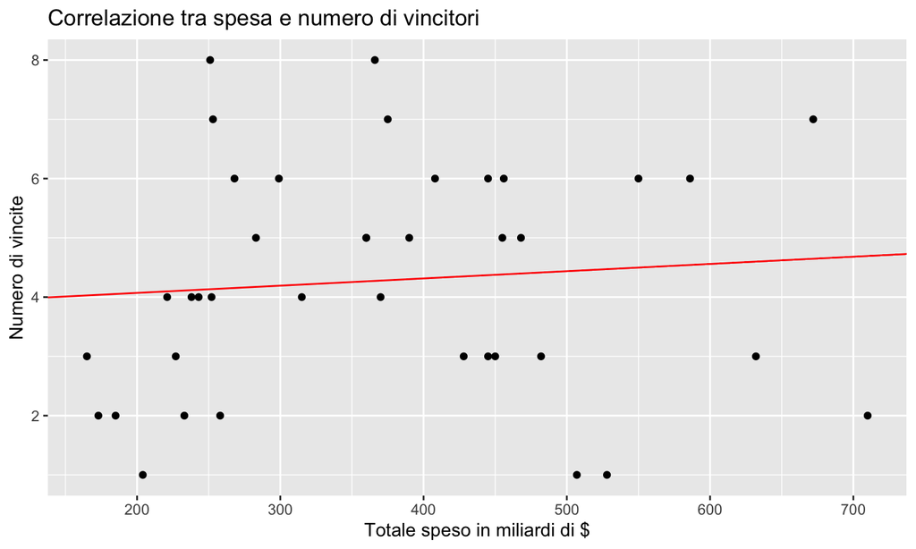

Possiamo quindi provare a predire.

! Per prendire meglio i risultati utilizziamo tutto il dataset quindi dal 1981 al 2021

## Quanti Nobel per gli USA nel 2022?

Proviamo ora effettivamente a predire il numero di vincite nel 2022.

Usiamo la funzione:

```r
predict(object = prova, newdata = subset(corrLast, Value = 703))
```

Otteniamo:

```
## [1] 4.69
```

Arrotondiamo a 5, abbiamo predetto **5** vincitori per il 2022, quanti sono stati in tutto? **6**, siamo andati molto vicini, possiamo quindi ritenerci sodisfatti.

Grazie per l’attenzione!